# Homework 8

## Problem 1: The infamous mule kick data 10pts

The file `mule_kicks.csv`, available for download (here)[https://kdlevin-uwstat.github.io/STAT340-Fall2021/hw/03/mule_kicks.csv], contains a simplified version of a very famous data set. The data consists of the number of soldiers killed by being kicked by mules or horses each year in a number of different companies in the Prussian army near the end of the 19th century.

This may seem at first to be a very silly thing to collect data about, but it is a very interesting thing to look at if you are interested in rare events. Deaths by horse kick were rare events that occurred independently of one another, and thus it is precisely the kind of process that we might expect to obey a Poisson distribution.

Download the data and read it into R by running

```r
download.file('https://kdlevin-uwstat.github.io/STAT340-Fall2021/hw/03/mule_kicks.csv', destfile='mule_kicks.csv')
mule_kicks = read.csv('mule_kicks.csv', header=TRUE)

head(mule_kicks)
```

```
##   deaths
## 1      0
## 2      0
## 3      0
## 4      0
## 5      0
## 6      0
```

`mule_kicks` contains a single column, called `deaths`. Each entry is the number of soldiers killed in one corps of the Prussian army in one year. There are 14 corps in the data set, studied over 20 years, for a total of 280 death counts.

### Part a: estimating the Poisson rate 3pts

Assuming that the mule kicks data follows a Poisson distribution, produce a point estimate for the rate parameter $\lambda$. There are no strictly right or wrong answers, here, though there are certainly better or worse ones.

```r
mean(mule_kicks$deaths)
```

```
## [1] 0.7
```

Assuming this is a Poisson, $\bar{X} = \lambda$.

### Part b: constructing a CI 4pts

Using everything you know (Monte Carlo, CLT, etc.), construct a confidence interval for the rate parameter $\lambda$. Explain in reasonable detail what you are doing and why you are constructing the confidence interval in this way (a few sentences is fine!).

```r
reps = replicate(1e4, mean(rpois(length(mule_kicks$deaths), mean(mule_kicks$deaths))))
quantile( reps, probs=c(0.025, 0.975) )
```

```
##      2.5%     97.5%
## 0.6035714 0.8000000
```

First we use our estimator $\bar{X}$ for $\lambda$, then under that assumption we sample data from the Poisson and use our estimator on the sample data. This should now provide us a distribution of estimators that we can take the quantile of to find the confidence interval.

### Part c: assessing a model 3pts

Here’s a slightly more open-ended question. We *assumed* that the data followed a Poisson distribution. This may or may not be a reasonable assumption. Use any and all tools that you know to assess (either with code or simply in words) how reasonable or unreasonable this assumption is.

Once again, there are no strictly right or wrong answers here. Explain and defend your decisions and thought processes in a reasonable way and you will receive full credit.

We will use a MC approach to compare the mean of observed distribution to samples from a real Poisson. By doing this we can find a p-value and statistical significance to support the hypothesis that the Poisson is an appropriate distribution or not.

The null hypothesis will be that the mean of the observed data is the mean of the Poisson, meaning the original was a Poisson.

The alternate hypothesis will be that the data is not sampled from the Poisson.

```r
reps = replicate(1e4, mean(rpois(length(mule_kicks$deaths), mean(mule_kicks$deaths))))
mean(mean(mule_kicks$deaths) >= reps)
```

```
## [1] 0.5134
```

We find that $p > .05$, so we reject the alternate hypothesis which implies the data is sampled from a Poisson.

## Problem 2: A Confidence interval for the median (8 points)

The following numbers were sampled from a population. You can assume they are independent and identically distributed (they are, in fact).

```r
mysteryData <- c(16.91,19.96,16.55,16.77,19.64,16.87,16.50,14.19,16.54,18.64,11.27,17.08)
```

We want to estimate the population median with a 95% confidence interval.

1. First assume that the population is normally distributed. Come up with estimates for the parameters of the normal distribution based on the data.

```r
mean(mysteryData)
```

```
## [1] 16.74333
```

```r
sd(mysteryData)
```

```
## [1] 2.318065
```

2. Construct a 95% confidence interval assuming the population is a normal distribution. Use the Monte Carlo Approach. Use 1000 Monte Carlo replicates.

```r
reps = replicate(1e3, median(rnorm(length(mysteryData), mean(mysteryData), sd(mysteryData))))
quantile( reps, probs=c(0.025, 0.975) )
```

```
##     2.5%    97.5%
## 15.32076 18.32337
```

3. Now assume that the population is uniformly distributed. Come up with estimates for the min and max of the uniform distribution using the method of moments. This is based on $\bar{X}$, the sample mean and $S$, the sample standard deviation. The point estimates for a and b are given by
   $$\bar{X} \pm \sqrt{3} S$$

```r
ab = mean(mysteryData) + sqrt(3) * c(-1, 1) * sd(mysteryData)
ab
```

```
## [1] 12.72833 20.75834
```

4. Construct a 95% confidence interval assuming the population is a uniform distribution. Use 1000 Monte Carlo replicates.

```r
reps = replicate(1e3, median(runif(length(mysteryData), ab[1], ab[2])))
quantile( reps, probs=c(0.025, 0.975) )
```

```
##     2.5%    97.5%
## 14.66469 18.69800
```

## Problem 3: Closing the loop 6 pts

In our discussion of the Universal Widgets of Madison company from lecture, we said that we were interested in two questions:

1. Estimating the probability $p$ that a widget is functional.
2. How many widgets should be in a batch to ensure that (with high probability) a batch ships with at least $5$ functional widgets in it?

We discussed question (1) at length in lecture. What about question (2)? Our client wants to know how many widgets should ship in each batch so as to ensure that the probability there are at least $5$ functional widgets in a batch is at least $0.99$.

Now, suppose that we have observed data and estimated $p$ to be $0.82$.

Use everything you know so far in this course to give a recommendation to the client. Be sure to explain clearly what you are doing and why. If there are any steps, assumptions, etc., that you are not 100% pleased with, feel free to point them out.

**Note:** there are at least two “obvious” ways to solve this problem. One is based on using Monte Carlo (i.e., assume $p=0.82$ is the truth, and try generating batches of different sizes, etc.). The other uses direct computation of probabilities, using basic facts about Binomial RVs. Neither of these is necessarily better than the other, and you do not need to use both approaches to receive full credit. Indeed, you are free to try doing something else entirely, if you wish. Just explain clearly what you are doing and why!

Want to find $n$ where $P(X >= 5) >= .99$, $X \sim Binom(.82, n)$.

We can try different $n$ starting from $5$ until $P(X >= 5) >= .99$.

There is the assumption that our point estimate is accurate for $p$, so the observed data should be analyzed closely to see if this is appropriate.

```r
for (i in 5:1e2) {
  if (1 - pbinom(4, size = i, prob = 0.82) >= 0.99) {
    print(i)
    break
  }
}
```

```
## [1] 10
```

The batch size should be at least 10.

## Problem 4: Estimating Coverage Rate (6 points)

Suppose we want to estimate the $p$ parameter from a Geometric distribution. By doing some research you would find that an unbiased estimator for $p$ is given as:

$$\hat{p} =
\frac{1}{1+\frac{n}{n-1}\bar{X}}$$

1. Create a plot that shows the coverage rate of a 95% confidence interval for samples of size 12 for values of p: .10, .20, …, .80, .90.
- To estimate the coverage rate, use 500 Monte Carlo replicates
- To construct each MC interval you should use 500 MC replicates

If this is taking too long to run, lower both of these to 200 replicates.

```r
set.seed(1)
p <- seq(.1,.9,.1)
coverage <- rep(0, length(p))
results <- data.frame(p, coverage)
NMC1 <- 500
NMC2 <- 500

head(results)
```

```
##     p coverage
## 1 0.1        0
## 2 0.2        0
## 3 0.3        0
## 4 0.4        0
## 5 0.5        0
## 6 0.6        0
```

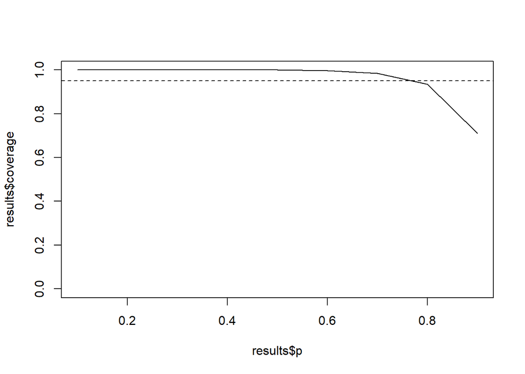

```r
for(j in 1:nrow(results)){
  # pull out the value p from the results data frame
  p <- results$p[j]
  # the 'contains' vector will be a collection of TRUE and FALSE, based
  # on whether each CI contains the value p
  contains <- rep(FALSE, NMC1)
  for(i in 1:NMC1){ #Construct NMC1 confidence intervals
    #generate some data initially from the geometric distribution
    data = rgeom(12, p)
    #calculate the unbiased estimate of p
    p.hat = 1 / (1 + (12 / (12 - 1)) * mean(data))
    #Now you want to use your p.hat to generate NMC2 sets of data
    #Each time you want to calcualte an unbiased phat, and store it.
    data = rgeom(NMC2, p.hat)
    #Your Monte Carlo Confidence interval should be based on
    #appropriate sample quantiles
    ci = quantile(data, c(0.025, 0.975))
    #print(ci)
    #Last, assign 'contains[i]' to be TRUE or FALSE based on
    #whether p is >= than the lower bound AND <= the
    #upper bound.
    contains[i] = p >= ci[1] && p <= ci[2]
  }
  results[j, "coverage"] <- mean(contains)
}
plot(x=results$p, y=results$coverage, ylim=c(min(coverage),1), type="l")
abline(h=.95, lty=2)
```

2. What do you observe? Does the coverage of MC intervals tend to be affected by the value of $p$? In what way?

It seems to be stable for $p <= .5$, then we see the coverage decrease as $p$ increases.